# Lab 3: GAMs, Prophet, and Several Seasons at Once

ECON 8310: Business Forecasting — University of Nebraska at Omaha

# What we are doing

Lecture 3 made a claim: a GAM earns its keep when a series has **several cycles running at once**, because each one gets its own smooth term and you can still read the model.

Retail sales cannot show you that — they have essentially one season. So today we leave M5 and use electricity demand, which has three large cycles simultaneously, and an annual shape that will break the first model we try.

The business question: you are forecasting daily demand for a grid operator. Being wrong is expensive in both directions — under-forecast and you buy power at spot prices, over-forecast and you have paid to keep generation spinning for nothing.

**Suggested time:** ~40 minutes · **You will need:** `pandas`, `numpy`, `matplotlib`, `prophet`, `pygam`, and `data/processed/electricity_daily.csv` + `electricity_hourly.csv` (run `python scripts/prep_electricity.py` once).

# Setup

```python
import pandas as pd
import numpy as np
import matplotlib.pyplot as plt
import warnings, logging
warnings.filterwarnings('ignore')
logging.getLogger('cmdstanpy').setLevel(logging.ERROR)   # Prophet is chatty; silence it

from pathlib import Path

def data_path(name):
    """Find the processed data file whether you render from the repo root or from
    this file's own folder."""
    for base in (Path.cwd(), *Path.cwd().parents):
        p = base / "data" / "processed" / name
        if p.exists():
            return p
    raise FileNotFoundError(
        f"Could not find data/processed/{name}. "
        "Run `python scripts/prep_electricity.py` from the repository root first."
    )

daily = pd.read_csv(data_path("electricity_daily.csv"), parse_dates=["date"])
hourly = pd.read_csv(data_path("electricity_hourly.csv"), parse_dates=["datetime"])

# Five and a half years is plenty of yearly cycles and keeps every fit under a second.
daily = daily[daily.date >= "2013-01-01"].reset_index(drop=True)

SPLIT = "2017-08-01"
train, test = daily[daily.date < SPLIT], daily[daily.date >= SPLIT]

rmse = lambda a, b: float(np.sqrt(np.mean((np.asarray(a) - np.asarray(b)) ** 2)))
mae  = lambda a, b: float(np.mean(np.abs(np.asarray(a) - np.asarray(b))))
results = {}

print(f"{len(daily)} days — train {len(train)}, test {len(test)}")
print(f"test window: {test.date.min():%Y-%m-%d} to {test.date.max():%Y-%m-%d}")
```

```
2041 days — train 1673, test 368
test window: 2017-08-01 to 2018-08-03
```

# Step 1 — Three cycles, one series

Before any model, look at the three periodicities separately.

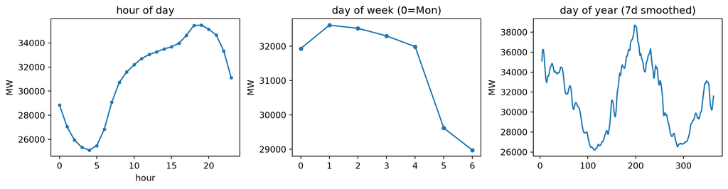

```python
fig, axes = plt.subplots(1, 3, figsize=(12, 3.2))

hourly.groupby("hour").mw.mean().plot(ax=axes[0], marker="o", ms=3)
axes[0].set_title("hour of day"); axes[0].set_xlabel("hour")

daily.groupby("dow").mw_mean.mean().plot(ax=axes[1], marker="o", ms=4)
axes[1].set_title("day of week (0=Mon)"); axes[1].set_xlabel("")

daily.groupby("doy").mw_mean.mean().rolling(7, center=True).mean().plot(ax=axes[2])
axes[2].set_title("day of year (7d smoothed)"); axes[2].set_xlabel("")

for a in axes: a.set_ylabel("MW")
plt.tight_layout()
```

```python
for label, g in [("hour of day", hourly.groupby("hour").mw.mean()),
                 ("day of week", daily.groupby("dow").mw_mean.mean()),
                 ("day of year", daily.groupby("doy").mw_mean.mean())]:
    swing = 100 * (g.max() - g.min()) / g.mean()
    print(f"{label:<14} swing {swing:5.1f}%   min {g.idxmin():>3}   max {g.idxmax():>3}")
```

```
hour of day    swing  33.3%   min   4   max  19
day of week    swing  11.6%   min   6   max   1
day of year    swing  44.7%   min 116   max 200
```

**Notice:** all three cycles are large — none is a rounding error you could ignore. This is the situation Lecture 3 said GAMs are for.

# Step 2 — The annual cycle has *two* peaks

Look again at the third panel. It does not look like a wave.

```python
doy = daily.groupby("doy").mw_mean.mean()
print(f"January  (days 1-31)    {doy.loc[1:31].mean():,.0f} MW   <- heating")
print(f"April    (days 95-115)  {doy.loc[95:115].mean():,.0f} MW   <- mild, nothing running")
print(f"July     (days 180-200) {doy.loc[180:200].mean():,.0f} MW   <- air conditioning")
```

```
January  (days 1-31)    34,403 MW   <- heating
April    (days 95-115)  26,945 MW   <- mild, nothing running
July     (days 180-200) 37,043 MW   <- air conditioning
```

Two peaks and two troughs per year, because heating and cooling are *both* electricity demand and they happen at opposite ends of the calendar.

Now the consequence. Fit the annual shape with a single sine wave, then with two.

```python
t = np.arange(len(doy))
one = np.c_[np.ones_like(t), np.sin(2*np.pi*t/365), np.cos(2*np.pi*t/365)]
two = np.c_[one,             np.sin(4*np.pi*t/365), np.cos(4*np.pi*t/365)]

for label, X in [("one harmonic", one), ("two harmonics", two)]:
    beta, *_ = np.linalg.lstsq(X, doy.values, rcond=None)
    print(f"{label:<15} in-sample RMSE {rmse(doy.values, X @ beta):,.0f} MW")
```

```
one harmonic    in-sample RMSE 3,428 MW
two harmonics   in-sample RMSE 1,348 MW
```

**This is the whole argument for a flexible term.** One harmonic can put its peak in summer or in winter — not both. Adding the second harmonic (a cycle that repeats *twice* a year) cuts the error by about a factor of two and a half.

Prophet’s `yearly_seasonality` is exactly this idea with more terms: a Fourier series of order 10 by default, so 10 sine/cosine pairs. A `pyGAM` spline gets there differently — by bending freely — but solves the same problem.

# Step 3 — Prophet, and an honest benchmark

Prophet wants two columns named `ds` and `y`. That is most of the API.

```python
from prophet import Prophet

# Benchmark first, always: same day last year (364 days keeps the weekday aligned).
lookup = daily.set_index("date").mw_mean
sn = [lookup.get(t - pd.Timedelta(days=364), np.nan) for t in test.date]
results["Seasonal naive (364d)"] = (rmse(test.mw_mean, sn), mae(test.mw_mean, sn))

m = Prophet(yearly_seasonality=True, weekly_seasonality=True, daily_seasonality=False)
m.fit(train.rename(columns={"date": "ds", "mw_mean": "y"})[["ds", "y"]])

fc = m.predict(test.rename(columns={"date": "ds"})[["ds"]])
results["Prophet"] = (rmse(test.mw_mean, fc.yhat), mae(test.mw_mean, fc.yhat))

for k, (r, a) in results.items():
    print(f"{k:<24} RMSE {r:7,.0f}   MAE {a:7,.0f}")
```

```
Seasonal naive (364d)    RMSE   4,608   MAE   3,333
Prophet                  RMSE   3,935   MAE   3,001
```

We turned `daily_seasonality` off deliberately — the data is one row per day, so there is no within-day variation left to model. Leave it on and Prophet will happily fit noise.

# Step 4 — The components plot

This is the payoff, and the reason Prophet gets used by people who will be questioned about their forecast.

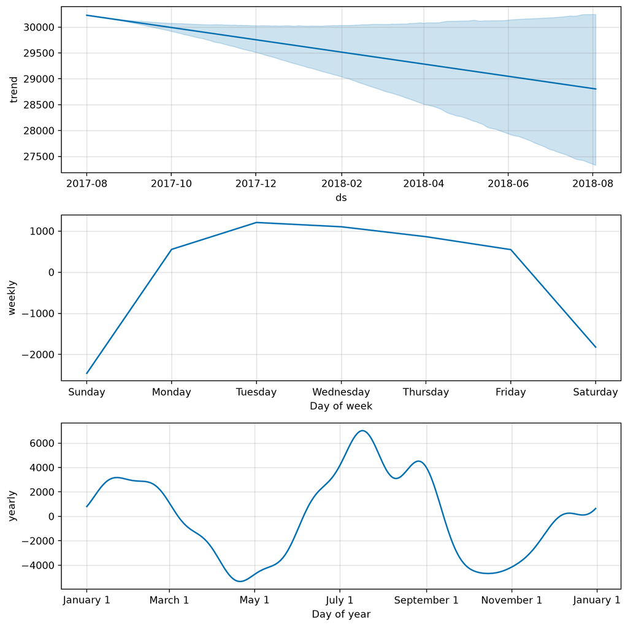

```python
m.plot_components(fc);
```

Three panels, one per additive term, each on the scale of the original series. The trend, the weekly cycle, the yearly cycle — separately readable.

**Notice** the yearly panel reproduces the double peak from Step 2. Nobody told Prophet about heating and cooling; the Fourier series had enough terms to find the shape.

# Step 5 — How much did the extra harmonics buy?

Step 2 argued this in-sample. Test it properly, on the holdout.

`yearly_seasonality` accepts an integer — the Fourier order — instead of `True`.

**Your turn:** fit a Prophet with the yearly order forced to **1** (a single harmonic) and add it to the results table.

```python
# ---- your turn: uncomment and fill in the order ----
# m1 = Prophet(yearly_seasonality=___, weekly_seasonality=True, daily_seasonality=False)
# m1.fit(train.rename(columns={"date": "ds", "mw_mean": "y"})[["ds", "y"]])
#
# fc1 = m1.predict(test.rename(columns={"date": "ds"})[["ds"]])
# results["Prophet (yearly order=1)"] = (rmse(test.mw_mean, fc1.yhat),
#                                        mae(test.mw_mean, fc1.yhat))
#
# print(f"single harmonic RMSE {rmse(test.mw_mean, fc1.yhat):,.0f}")
```

Report both numbers. Does the holdout agree with what Step 2 predicted in-sample?

# Step 6 — pyGAM, and reading the smooth directly

Prophet is a GAM with the time-series decisions made for you. `pyGAM` makes you state the terms, which is more work and more control.

```python
from pygam import LinearGAM, s, f

# s(0) = cyclic spline on day-of-year (basis="cp" makes Dec 31 join Jan 1)
# f(1) = day-of-week as a categorical factor
X_tr, X_te = train[["doy", "dow"]].values, test[["doy", "dow"]].values

gam = LinearGAM(s(0, n_splines=20, basis="cp") + f(1)).fit(X_tr, train.mw_mean.values)
results["pyGAM (doy + dow)"] = (rmse(test.mw_mean, gam.predict(X_te)),
                                mae(test.mw_mean, gam.predict(X_te)))

print(f"effective degrees of freedom: {gam.statistics_['edof']:.1f}")
print(pd.DataFrame(results, index=["RMSE", "MAE"]).T
        .sort_values("RMSE").round(0).astype(int).to_string())
```

```
effective degrees of freedom: 22.5
                       RMSE   MAE
pyGAM (doy + dow)      3444  2550
Prophet                3935  3001
Seasonal naive (364d)  4608  3333
```

Now the partial dependence — the GAM equivalent of the components plot.

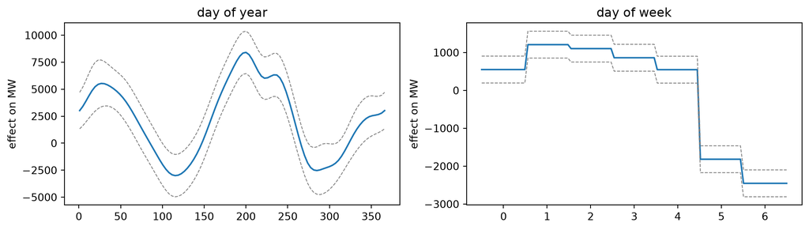

```python
fig, axes = plt.subplots(1, 2, figsize=(11, 3.2))
for i, (ax, name) in enumerate(zip(axes, ["day of year", "day of week"])):
    XX = gam.generate_X_grid(term=i)
    pdep, ci = gam.partial_dependence(term=i, X=XX, width=0.95)
    ax.plot(XX[:, i], pdep)
    ax.plot(XX[:, i], ci, c="grey", ls="--", lw=0.8)
    ax.set_title(name); ax.set_ylabel("effect on MW")
plt.tight_layout()
```

**Read the left panel and say what it means in words**, the way you would to a grid operator. The confidence band widens where the data is thin — say that too.

# Before you leave

You should have found that every method beat the seasonal-naive benchmark **on RMSE**, and that the single harmonic was the worst of the three models.

Look at the MAE column before you move on. The single-harmonic Prophet has a *worse* MAE than the benchmark it beat on RMSE. Same two models, same holdout, opposite verdict depending on which error measure you quote — because RMSE squares errors and so punishes the occasional large miss, while MAE treats every error proportionally.

> Give one reason a more flexible model can lose on a held-out year, and name the thing you would check before concluding that pyGAM is genuinely the better choice here.

> And the operational question: your forecast is for a grid operator who must buy generation in advance. Under-forecasting and over-forecasting cost different amounts. Which of these models would you actually ship, and what would you need to know first?

*Solutions posted to Canvas after class.*